# multivariante_proIII

David

2024-05-31

# Multivariat Survival Analysis in Lung Cancer Patients Treated with Prelozumb

## INTRODUCTION:

In this study, we analyzed a dataset of 34 lung cancer patients who were treated with Prelozumb. The primary objective is to determine which factors influence the survival of these patients. Various clinical and demographic variables were considered in the analysis, including age, body mass index (BMI), PD-L1 levels, LDH, total proteins, albumin, tobacco exposure, and percentage of weight loss, among others.

- Edad_dx (Age at Diagnosis): This variable represents the age of the patients at the time of lung cancer diagnosis. Age is a critical factor in cancer prognosis and can influence treatment outcomes.
- IMC (Body Mass Index): BMI is included to evaluate the nutritional and health status of patients, which can affect their overall survival and response to cancer therapy.
- Porcentaje_perdpeso (Percentage of Weight Loss): This indicates the percentage of weight loss experienced by the patient before the treatment initiation, serving as an indicator of cancer cachexia and overall health deterioration.
- Exp_tab (Smoking Exposure in Pack-Years): Given the strong association between lung cancer and tobacco use, this variable quantifies the extent of smoking in pack-years, providing insights into the risk profile of each patient.
- PD_L1 (Expression Level): PD-L1 expression levels are measured to determine the likelihood of response to anti-PD-L1 therapies like Prelozumb. Higher levels are often associated with a better response to immunotherapy.

**Lab Values (LDH, Prot_tot, Albumina):**

- LDH (Lactate Dehydrogenase): An enzyme that, when elevated, can indicate tissue damage and has prognostic significance in cancer.
- Prot_tot (Total Protein) and Albumina (Albumin): These markers of nutritional status and liver function are essential for assessing the patient’s general health and potential complications.

**Clinical Dates:**

- Fecha_nac (Date of Birth) and Fecha_dx (Date of Diagnosis): These dates are fundamental for calculating the age at diagnosis and understanding the timeline of each patient’s disease progression.
- Fecha_inicio_pem (Date of Treatment Initiation): The start date of Prelozumb treatment, critical for survival analysis.
- Fecha_SLP (Date of SLP Event) and Fecha_exitus (Date of Death or Last Follow-up): These endpoints are used to calculate survival times, crucial for the analysis of treatment effectiveness.

**Censoring Indicators (SLP_cens, SG_cens):** These binary variables indicate whether the survival data for SLP (and overall survival, SG) are censored, meaning the event of interest (death or progression) has not been observed during the study period.

The analysis will involve transforming these variables appropriately, calculating survival times, and applying statistical models to understand the impact of Prelozumb on patient survival. This R Markdown document will detail the methods, present the statistical findings, and discuss the implications of the results in the context of ongoing cancer research and clinical practice.

## Data Preparation

The following details the data loading and preparation process:

```r
# Data loading
datos <- read.csv(file = "./df_supervivencia.csv", header = TRUE)

# Convert date columns to date objects
datos$Fecha_dx <- as.Date(datos$Fecha_dx, format = "%Y-%m-%d")
datos$Fecha_SG <- as.Date(datos$Fecha_SG, format = "%Y-%m-%d")

# Calculate survival time in weeks
datos$Tiempo_Supervivencia <- as.numeric(difftime(datos$Fecha_SG, datos$Fecha_dx, units = "weeks"))

# Convert categorical variables to factors
datos$Sexo <- factor(datos$Sexo, labels = c("Mujer", "Hombre"))
datos$Exitus <- factor(datos$Exitus, labels = c("No", "Si"))
datos$Hab_tabaq <- factor(datos$Hab_tabaq, labels = c("No", "Si", "ex-fumador"))
datos$Toxicidad <- factor(datos$Toxicidad, labels = c("No", "Si"))
datos$Progresion <- factor(datos$Progresion, labels = c("No", "Si"))

# Check the first records
head(datos)
```

```
##   X Edad_dx      IMC Porcentaje_perdpeso Exp_tab PD_L1 Col_total LDH Prot_tot
## 1 1      46 28.08899              0.0458      20   100       217 163      7.0
## 2 2      68 35.37981              0.0000       0    70       154 171      6.0
## 3 3      59 25.71101              0.0000      45    50       146 197      7.2
## 4 4      72 28.24859              0.0000      92     2       149 159      7.1
## 5 5      50 29.05475              0.1000      55    60       210 198      7.9
## 6 6      71 28.83059              0.0000     200    90       162 220      8.0
##   Albumina      PCR   Hb Leucoc_tot Neutrofilos Linf_tot Plaquetas NLR_pre
## 1      4.1 39.73077 15.3      10100        8000     1400    273000    5.71
## 2      3.7 39.73077 11.8       9800        8200      800    124000   10.25
## 3      4.3  7.00000 16.7       9900        7400     1400    349000    5.29
## 4      4.0  6.00000 14.6       5600        3000     1800    220000    1.67
## 5      4.4  8.00000 15.7       8900        5300     2300    350000    2.30
## 6      4.3 24.00000 13.1       8800        6000     1600    279000    3.75
##   PLR_pre PNI_pre ALI_pre   SII_pre LinfT_cel porc_linf_T CD4_cel porc_CD4
```

[output cut: 90 more lines]

## Data Preparation Process Description

Data Loading: The data is imported from a CSV file containing detailed information about the patients. Date Conversion: Columns corresponding to the diagnosis date (Fecha_dx) and the survival event date (Fecha_SG) are converted to date objects to facilitate calculations. Survival Time Calculation: Survival time in weeks is calculated by subtracting the diagnosis date from the event date. Conversion of Categorical Variables: Several categorical variables are converted to factors with descriptive labels. This includes the patient’s sex, whether the patient has died (Exitus), smoking habits (Hab_tabaq), presence of toxicity (Toxicidad), and disease progression (Progresion).

# Exploratory Data Analysis (EDA)

```r
censura_proporciones <- prop.table(table(datos$SG_cens)) * 100
censura_proporciones
```

```
##
##        0        1
## 67.64706 32.35294
```

## Proportion of Censored Data

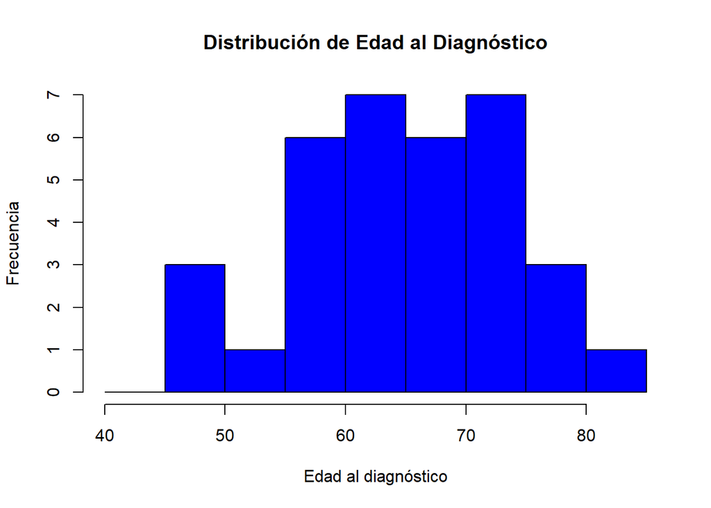

```r
hist(datos$Edad_dx, breaks=seq(40, 85, 5), main="Distribución de Edad al Diagnóstico", xlab="Edad al diagnóstico", ylab="Frecuencia", col="blue", border="black")
```

## Histogram of Age at Diagnosis

We also visualize the distribution of age at diagnosis to understand the age demographics of the patients in the study. - X-Axis (Edad_dx): This axis represents the age in years at the time of diagnosis of the patients. Ages are grouped into intervals, which appear to be approximately 5 years each.

```r
# Cross-tabulations of Categorical Variables with Censorship
sexo_censura <- table(datos$Sexo, datos$SG_cens)
exitus_censura <- table(datos$Exitus, datos$SG_cens)
habito_tabaquico_censura <- table(datos$Hab_tabaq, datos$SG_cens)
toxicidad_censura <- table(datos$Toxicidad, datos$SG_cens)
progresion_censura <- table(datos$Progresion, datos$SG_cens)

# Grouping Age and Cross-tabulation with Censorship
datos$Edadg <- cut(datos$Edad_dx, breaks=c(40, 55, 70, 85))
edad_censura <- table(datos$Edadg, datos$SG_cens)

list(sexo_censura, exitus_censura, habito_tabaquico_censura, toxicidad_censura, progresion_censura, edad_censura)
```

```
## [[1]]
##
##           0  1
##   Mujer   7  3
##   Hombre 16  8
##
## [[2]]
##
##       0  1
##   No  1  9
##   Si 22  2
##
## [[3]]
##
##               0  1
##   No          1  3
##   Si         13  2
##   ex-fumador  9  6
##
## [[4]]
##
##       0  1
##   No 15  1
##   Si  8 10
##
## [[5]]
##
##       0  1
##   No  4  9
##   Si 19  2
##
## [[6]]
##
##            0  1
##   (40,55]  2  2
##   (55,70] 15  4
##   (70,85]  6  5
```

## Cross-tabulations of Categorical Variables with Censorship

Next, we create cross-tabulations to explore the relationship between categorical variables and the censoring status. This helps in understanding how different factors might be associated with censored observations.

## Grouping Age and Cross-tabulation with Censorship

To further analyze the effect of age on censorship, we group ages into intervals and cross-tabulate with the censorship status.

## Cox regresion

To determine which variables are significant in a multivariate survival analysis, we first perform a univariate Cox regression analysis for each individual variable. This allows us to see which variables have a significant association with survival time before including them in a multivariate model.

```r
# Create the Surv object
surv_object <- Surv(time = datos$Tiempo_Supervivencia, event = datos$SG_cens)

# List of variables to analyze
variables <- c("Edad_dx", "IMC", "Porcentaje_perdpeso", "Exp_tab", "PD_L1",
               "LDH", "Prot_tot", "Albumina", "Sexo", "Exitus",
               "Hab_tabaq", "Toxicidad", "Progresion")

# Cox regression analysis
univ_results <- lapply(variables, function(var) {
  formula <- as.formula(paste("surv_object ~", var))
  model <- coxph(formula, data = datos)
  return(summary(model))
})

p_values <- sapply(univ_results, function(result) result$coefficients[, "Pr(>|z|)"])
names(p_values) <- variables
p_values
```

```
## $Edad_dx
## [1] 0.78265
##
## $IMC
## [1] 0.3560753
##
## $Porcentaje_perdpeso
## [1] 0.6789045
##
## $Exp_tab
## [1] 0.7522426
##
## $PD_L1
## [1] 0.3168469
##
## $LDH
## [1] 0.9596877
##
## $Prot_tot
## [1] 0.7247923
##
## $Albumina
## [1] 0.6708608
##
## $Sexo
## [1] 0.3157489
##
## $Exitus
## [1] 0.6242251
##
## $Hab_tabaq
##         Hab_tabaqSi Hab_tabaqex-fumador
##           0.4931773           0.4274770
##
## $Toxicidad
## [1] 0.3327293
##
## $Progresion
## [1] 0.2634302
```

The high variability of p-values can be due to several factors, especially when working with a limited number of samples:

- Sample Size: With only 34 samples, there may not be enough statistical power to detect significant effects.
- Collinearity: There may be high collinearity between some predictor variables, which can inflate standard errors and make significance tests less powerful.
- Event Distribution: The distribution of censored events versus observed events can affect the results. If most events are censored, it can be difficult to detect significant associations.

The next step involves addressing these challenges by considering the inclusion of significant variables in a multivariate Cox regression model, adjusting for potential confounders, and ensuring the robustness of the findings through additional diagnostic tests and validation techniques.

## Collinearity evaluation

To evaluate collinearity, we calculate the Variance Inflation Factor (VIF) for the variables in our Cox regression model. VIF values help identify multicollinearity by quantifying how much the variance of a regression coefficient is inflated due to collinearity with other predictors.

```r
vif_cox <- coxph(surv_object ~ Edad_dx + IMC + Porcentaje_perdpeso + Exp_tab + PD_L1 +
                 LDH + Prot_tot + Albumina + Sexo + Exitus +
                 Hab_tabaq + Toxicidad + Progresion, data = datos)
```

```
## Warning in coxph.fit(X, Y, istrat, offset, init, control, weights = weights, :
## Ran out of iterations and did not converge
```

```r
vif(vif_cox)
```

```
## Warning in vif.default(vif_cox): No intercept: vifs may not be sensible.
```

```
##                     GVIF Df GVIF^(1/(2*Df))
## Edad_dx                1  1               1
## IMC                    1  1               1
## Porcentaje_perdpeso    1  1               1
## Exp_tab                1  1               1
## PD_L1                  1  1               1
## LDH                    1  1               1
## Prot_tot               1  1               1
## Albumina               1  1               1
## Sexo                   1  1               1
## Exitus                 1  1               1
## Hab_tabaq              1  2               1
## Toxicidad              1  1               1
## Progresion             1  1               1
```

The warning about the lack of intercept suggests that the model needs adjustments. All VIFs being equal to 1 indicates no multicollinearity detected among the predictor variables in this case. However, this result is suspicious and could be related to convergence issues.

## Visualizing Survival

We create Kaplan-Meier survival curves for different groups of categorical variables to visually explore survival patterns.

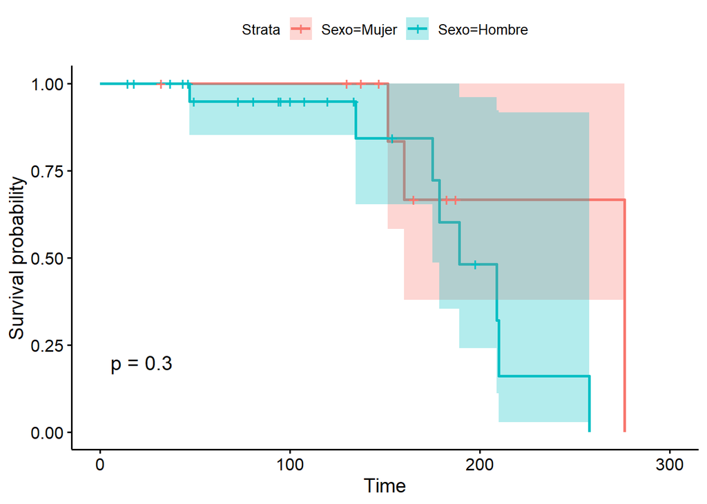

```r
# Kaplan-Meier curve for Gender
ggsurvplot(survfit(Surv(Tiempo_Supervivencia, SG_cens) ~ Sexo, data = datos),
           conf.int = TRUE,
           pval = TRUE)
```

The Kaplan-Meier curve for Sexo (gender) represents the survival probability of patients based on their gender. The following information is presented in the graph: - Survival Probability: The y-axis shows the probability of survival, while the x-axis represents time in weeks. - Survival Curves: Two curves are plotted: - The red curve represents female patients (Sexo = Woman). - The blue curve represents male patients (Sexo = Man). - Confidence Intervals: The shaded areas around the curves represent the 95% confidence intervals for the survival probability. - Log-rank Test: The p-value displayed on the plot (p = 0.3) indicates the statistical significance of the difference in survival between the two gender groups. A p-value greater than 0.05 suggests that there is no significant difference in survival between female and male patients.

The Kaplan-Meier curve for gender reveals that the survival probability does not significantly differ between female and male patients, with a p-value of 0.3.

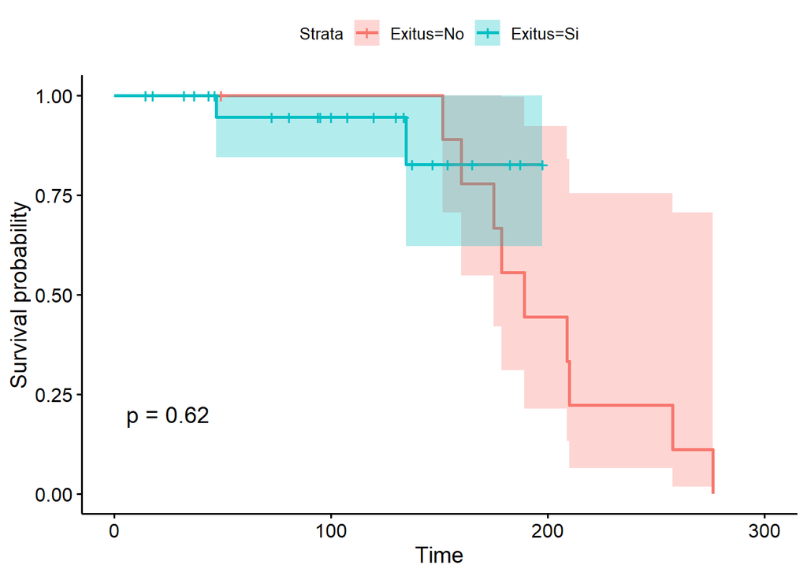

```r
# Kaplan-Meier curve for Exitus
ggsurvplot(survfit(Surv(Tiempo_Supervivencia, SG_cens) ~ Exitus, data = datos),
           conf.int = TRUE,
           pval = TRUE)
```

The Kaplan-Meier curve for Exitus represents the survival probability of patients based on their Exitus status, which indicates whether the patient has died (Exitus = 1) or not (Exitus = 0). The following information is presented in the graph: - Survival Probability: The y-axis shows the probability of survival, while the x-axis represents time in weeks. - Survival Curves: Two curves are plotted: - The red curve represents patients who have not died (Exitus = 0). - The blue curve represents patients who have died (Exitus = 1). - Confidence Intervals: The shaded areas around the curves represent the 95% confidence intervals for the survival probability. - Log-rank Test: The p-value displayed on the plot (p = 0.62) indicates the statistical significance of the difference in survival between the two groups. A p-value greater than 0.05 suggests that there is no significant difference in survival between patients who have died and those who have not.

The Kaplan-Meier curve for Exitus shows that there is no significant difference in survival between patients who have died and those who have not, as indicated by the p-value of 0.62.

## Adjusting the Cox Model with Selected Variables

To refine our analysis, we adjusted the Cox regression model using only the variables that seem most relevant and less problematic. This will help identify the variables that have a greater influence on the patients’ survival time.

```r
# Create a Surv object
surv_object <- Surv(time = datos$Tiempo_Supervivencia, event = datos$SG_cens)

# Fit the Cox regression model with selected variables
cox_model <- coxph(surv_object ~ Edad_dx + IMC + Exp_tab + PD_L1 + Progresion, data = datos)

# Summary of the model
summary(cox_model)
```

```
## Call:
## coxph(formula = surv_object ~ Edad_dx + IMC + Exp_tab + PD_L1 +
##     Progresion, data = datos)
##
##   n= 34, number of events= 11
##
##                    coef  exp(coef)   se(coef)      z Pr(>|z|)
## Edad_dx      -0.0033348  0.9966708  0.0334657 -0.100    0.921
## IMC          -0.0717859  0.9307302  0.0744578 -0.964    0.335
## Exp_tab      -0.0004402  0.9995599  0.0077235 -0.057    0.955
## PD_L1         0.0046836  1.0046946  0.0241018  0.194    0.846
## ProgresionSi -0.9492143  0.3870450  1.0080689 -0.942    0.346
##
##              exp(coef) exp(-coef) lower .95 upper .95
## Edad_dx         0.9967     1.0033   0.93340     1.064
## IMC             0.9307     1.0744   0.80435     1.077
## Exp_tab         0.9996     1.0004   0.98454     1.015
## PD_L1           1.0047     0.9953   0.95834     1.053
## ProgresionSi    0.3870     2.5837   0.05367     2.791
##
## Concordance= 0.663  (se = 0.087 )
## Likelihood ratio test= 2.81  on 5 df,   p=0.7
## Wald test            = 2.58  on 5 df,   p=0.8
## Score (logrank) test = 2.82  on 5 df,   p=0.7
```

Interpretation of Results - Age at Diagnosis (Edad_dx): The coefficient is -0.003348 with a p-value of 0.921, indicating that age does not have a significant association with survival time. - Body Mass Index (IMC): The coefficient is -0.071789 with a p-value of 0.335, suggesting that BMI also does not have a significant association with survival time. - Tobacco Exposure (Exp_tab): The coefficient is -0.0004402 with a p-value of 0.955, indicating a lack of significant association. - PD-L1: The coefficient is 0.0046836 with a p-value of 0.846, showing no significant association with survival. - Disease Progression (Progresion): The coefficient is -0.9492143 with a p-value of 0.346, suggesting no significant association with survival time.

Model Evaluation - Concordance: The concordance index is 0.663 (se = 0.087), indicating a moderate ability of the model to distinguish between individuals who experienced the event and those who did not. - Significance Tests: - Likelihood ratio test: p-value = 0.7 - Wald test: p-value = 0.8 - Score (logrank) test: p-value = 0.7

These results suggest that none of the variables included in the model have a significant association with the patients’ survival time. Additionally, the global significance tests (Likelihood ratio, Wald, and Score) indicate that the model as a whole is not significant.

## Using Cross-Validation to Evaluate Model Stability

Given the limited sample size, using cross-validation techniques can help evaluate the stability of the Cox model. Here, we perform bootstrap cross-validation to assess the variability and robustness of the model coefficients.

```r
# Function to fit the Cox model
cox_model_fn <- function(data, indices) {
  d <- data[indices,]
  fit <- coxph(Surv(time = d$Tiempo_Supervivencia, event = d$SG_cens) ~ Edad_dx + IMC + Exp_tab + PD_L1 + Progresion, data = d)
  return(coef(fit))
}

# Perform bootstrap cross-validation
results <- boot(data = datos, statistic = cox_model_fn, R = 300)
print(results)
```

```
##
## ORDINARY NONPARAMETRIC BOOTSTRAP
##
##
## Call:
## boot(data = datos, statistic = cox_model_fn, R = 300)
##
##
## Bootstrap Statistics :
##          original       bias    std. error
## t1* -0.0033347815   0.33513849    5.160728
## t2* -0.0717858923  -0.61364268   12.251576
## t3* -0.0004401621  -0.08021732    1.301834
## t4*  0.0046835902  -0.20040462    4.299818
## t5* -0.9492143374 -19.41556166  101.449015
```

Interpretation of Cross-Validation Results - Bias: The bootstrap results show the bias for each coefficient. A high bias indicates that the coefficient estimates may be unstable. - Standard Error: The standard errors are quite large, suggesting high variability in the coefficient estimates.

The cross-validation results indicate that the model coefficients have high standard errors and biases, likely due to the small sample size and inherent variability.

## Exploring Alternative and Simplified Models

To identify significant associations, we attempt to fit a simplified Cox regression model with fewer predictors. This approach helps determine if reducing the model complexity can reveal significant predictors of survival.

```r
# Fit a simplified Cox model
cox_model_simplificado <- coxph(surv_object ~ Edad_dx + Progresion, data = datos)
summary(cox_model_simplificado)
```

```
## Call:
## coxph(formula = surv_object ~ Edad_dx + Progresion, data = datos)
##
##   n= 34, number of events= 11
##
##                   coef exp(coef)  se(coef)      z Pr(>|z|)
## Edad_dx      -0.005765  0.994252  0.034248 -0.168    0.866
## ProgresionSi -0.942532  0.389640  0.840085 -1.122    0.262
##
##              exp(coef) exp(-coef) lower .95 upper .95
## Edad_dx         0.9943      1.006   0.92970     1.063
## ProgresionSi    0.3896      2.566   0.07509     2.022
##
## Concordance= 0.637  (se = 0.107 )
## Likelihood ratio test= 1.48  on 2 df,   p=0.5
## Wald test            = 1.28  on 2 df,   p=0.5
## Score (logrank) test = 1.36  on 2 df,   p=0.5
```

- Age at Diagnosis (Edad_dx): The coefficient is -0.005765 with a p-value of 0.866, indicating that age does not have a significant association with survival time.
- Disease Progression (Progresion): The coefficient is -0.942532 with a p-value of 0.262, suggesting that disease progression also does not have a significant association with survival time.

Model Evaluation - Concordance: The concordance index is 0.637 (se = 0.107), indicating a moderate ability of the model to distinguish between individuals who experienced the event and those who did not. However, it is still moderate and not particularly high. - Significance Tests: - Likelihood ratio test: p-value = 0.5 - Wald test: p-value = 0.5 - Score (logrank) test: p-value = 0.5 These results suggest that neither of the variables (Age at Diagnosis and Disease Progression) has a p-value less than 0.05, indicating no significant associations with survival time. Additionally, the high p-values from the global significance tests (Likelihood ratio, Wald, and Score) suggest that the model as a whole is not significant.

## Proceeding with the Cox Model Despite Setbacks

Despite the challenges, we proceed with fitting a Cox regression model with multiple variables to assess their associations with survival time.

```r
# Create the Surv object
surv_object <- Surv(time = datos$Tiempo_Supervivencia, event = datos$SG_cens)

# Fit the Cox regression model with multiple variables
cox_mult <- coxph(surv_object ~ Edad_dx + IMC + Porcentaje_perdpeso + Exp_tab + PD_L1 +
                  LDH + Prot_tot + Albumina + Sexo + Exitus +
                  Hab_tabaq + Toxicidad + Progresion, data = datos)

# Summary of the model
summary(cox_mult)
```

```
## Call:
## coxph(formula = surv_object ~ Edad_dx + IMC + Porcentaje_perdpeso +
##     Exp_tab + PD_L1 + LDH + Prot_tot + Albumina + Sexo + Exitus +
##     Hab_tabaq + Toxicidad + Progresion, data = datos)
##
##   n= 34, number of events= 11
##
##                           coef  exp(coef)   se(coef)      z Pr(>|z|)
## Edad_dx              3.901e+00  4.943e+01  3.755e+01  0.104    0.917
## IMC                 -7.399e+00  6.116e-04  9.382e+01 -0.079    0.937
## Porcentaje_perdpeso  1.146e+02  5.665e+49  8.759e+03  0.013    0.990
## Exp_tab             -2.330e-01  7.922e-01  9.154e+00 -0.025    0.980
## PD_L1                2.065e+00  7.884e+00  3.890e+01  0.053    0.958
## LDH                  2.533e-01  1.288e+00  4.249e+00  0.060    0.952
## Prot_tot            -1.183e+02  4.064e-52  6.676e+02 -0.177    0.859
## Albumina             1.872e+02  2.051e+81  1.958e+03  0.096    0.924
## SexoHombre           2.829e+00  1.692e+01  1.789e+03  0.002    0.999
## ExitusSi             7.733e+01  3.839e+33  4.099e+03  0.019    0.985
## Hab_tabaqSi          1.371e+02  3.406e+59  1.447e+03  0.095    0.925
## Hab_tabaqex-fumador  1.154e+02  1.356e+50  9.356e+02  0.123    0.902
## ToxicidadSi          1.654e+02  6.809e+71  1.423e+03  0.116    0.907
## ProgresionSi        -6.414e+01  1.395e-28  1.249e+03 -0.051    0.959
##
##                     exp(coef) exp(-coef) lower .95 upper .95
## Edad_dx             4.943e+01  2.023e-02 5.365e-31 4.554e+33
## IMC                 6.116e-04  1.635e+03 8.478e-84 4.412e+76
## Porcentaje_perdpeso 5.665e+49  1.765e-50 0.000e+00       Inf
## Exp_tab             7.922e-01  1.262e+00 1.279e-08 4.907e+07
## PD_L1               7.884e+00  1.268e-01 6.154e-33 1.010e+34
## LDH                 1.288e+00  7.762e-01 3.112e-04 5.333e+03
## Prot_tot            4.064e-52  2.461e+51 0.000e+00       Inf
## Albumina            2.051e+81  4.875e-82 0.000e+00       Inf
## SexoHombre          1.692e+01  5.909e-02 0.000e+00       Inf
## ExitusSi            3.839e+33  2.605e-34 0.000e+00       Inf
## Hab_tabaqSi         3.406e+59  2.936e-60 0.000e+00       Inf
## Hab_tabaqex-fumador 1.356e+50  7.376e-51 0.000e+00       Inf
## ToxicidadSi         6.809e+71  1.469e-72 0.000e+00       Inf
## ProgresionSi        1.395e-28  7.170e+27 0.000e+00       Inf
##
## Concordance= 1  (se = 0 )
## Likelihood ratio test= 41.52  on 14 df,   p=1e-04
## Wald test            = 0.11  on 14 df,   p=1
## Score (logrank) test = 20.31  on 14 df,   p=0.1
```

- None of the individual variables has a p-value less than 0.05, indicating that they do not significantly predict survival time.
- Concordance: The model shows a perfect concordance (1), but this is likely an artifact due to the small sample size and high model complexity.
- Global Tests:
  - Likelihood ratio test: p-value = 1e-04, suggesting that the model as a whole is significant.
  - Wald test: p-value = 1, indicating that the variables collectively do not significantly predict survival.
  - Score (logrank) test: p-value = 0.1, also indicating a lack of significance for the model.

Despite the high likelihood ratio test significance, the individual variable p-values and the Wald and Score tests suggest that the model’s variables are not significant predictors of survival. This discrepancy might be due to the small sample size and the inherent variability.

## Continuing with Cross-Validation to Evaluate Model Stability and Coefficient Variability

We use bootstrap cross-validation to assess the stability of the Cox regression model and the variability of the coefficients. This method helps us understand how the coefficients vary with different subsets of the data, providing insights into the model’s robustness.

```r
# Function to fit the Cox model
cox_model_fn <- function(data, indices) {
  d <- data[indices,]
  fit <- coxph(Surv(time = d$Tiempo_Supervivencia, event = d$SG_cens) ~ Edad_dx + IMC + Porcentaje_perdpeso + Exp_tab + PD_L1 +
               LDH + Prot_tot + Albumina + Sexo + Exitus +
               Hab_tabaq + Toxicidad + Progresion, data = d)
  return(coef(fit))
}
results <- boot(data = datos, statistic = cox_model_fn, R = 150)
results
```

```
##
## ORDINARY NONPARAMETRIC BOOTSTRAP
##
##
## Call:
## boot(data = datos, statistic = cox_model_fn, R = 150)
##
##
## Bootstrap Statistics :
##          original       bias    std. error
## t1*     3.9005155   -4.3868220   12.907060
## t2*    -7.3993849    5.3748459   15.026112
## t3*   114.5610641 -115.2451146 1515.173155
## t4*    -0.2329741   -0.1717879    4.783367
## t5*     2.0647732   -1.6198014    6.440118
## t6*     0.2533155   -0.4688187    1.604107
## t7*  -118.3323099  127.1764000  262.945713
## t8*   187.2278078 -205.1061494  399.153919
## t9*     2.8287410  -20.9697645  260.631559
## t10*   77.3306066  -64.2689395  173.889763
## t11*  137.0779815  -86.5018318  293.656255
## t12*  115.4336049  -66.2153155  229.277597
## t13*  165.4017181 -156.1134038   88.992288
## t14*  -64.1396896   38.5141628  102.433181
```

The results of this second Cox model that includes all variables regardless of their importance after the cross validation eschema reflect the great disparity in the values of bias and standard error between variables. As expected due to their significance some variables have a very high error and bias in absolute terms as in the case of the percentage of weight loss or toxicity, while values of other variables suffer hardly any of these metrics (see tobacco exposure or PD_L1).

All these cross-validation results indicate that the model coefficients suggests instability in the coefficients. This instability is common with small sample sizes and potential collinearity issues between all variables.

## Evaluating Proportional Hazards Assumption

We use diagnostics plots to evaluate the proportional hazards assumption in the Cox regression model. The plot below shows the DFBETA residuals for each variable in the model.

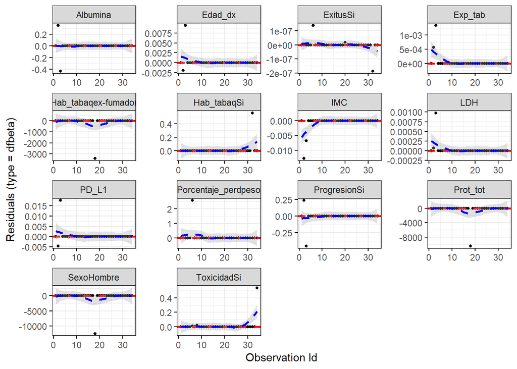

```r
# Evaluar la proporcionalidad de riesgos
ggcoxdiagnostics(cox_mult, type = "dfbeta")
```

*Key Observations*

- Low and Consistent Residuals: Most variables show low and consistent DFBETA residuals, indicating that the majority of observations do not disproportionately influence the model coefficients.
- Flat Trend Lines: The trend lines are relatively flat and close to zero, suggesting that no single observation is disproportionately influencing the model coefficients.
- Outliers: Some variables (e.g., IMC, Progresion, ToxicidadSi) have points outside the confidence bands, indicating that these observations have a stronger influence on the model.

## Proportional Hazards Assumption and Model Diagnostics

We continue with a detailed analysis of the proportional hazards assumption using diagnostic plots. Below, we evaluate the residuals and proportional hazards assumption for a simplified Cox model that includes Edad_dx, Progresion, and IMC.

```r
# Fit simplified Cox model
cox_model_simplificado <- coxph(Surv(time = datos$Tiempo_Supervivencia, event = datos$SG_cens) ~ Edad_dx + Progresion + IMC, data = datos)
summary(cox_model_simplificado)
```

```
## Call:
## coxph(formula = Surv(time = datos$Tiempo_Supervivencia, event = datos$SG_cens) ~
##     Edad_dx + Progresion + IMC, data = datos)
##
##   n= 34, number of events= 11
##
##                   coef exp(coef)  se(coef)      z Pr(>|z|)
## Edad_dx      -0.005256  0.994758  0.030623 -0.172    0.864
## ProgresionSi -1.056875  0.347540  0.854348 -1.237    0.216
## IMC          -0.076056  0.926764  0.070580 -1.078    0.281
##
##              exp(coef) exp(-coef) lower .95 upper .95
## Edad_dx         0.9948      1.005   0.93681     1.056
## ProgresionSi    0.3475      2.877   0.06513     1.855
## IMC             0.9268      1.079   0.80703     1.064
##
## Concordance= 0.674  (se = 0.085 )
## Likelihood ratio test= 2.77  on 3 df,   p=0.4
## Wald test            = 2.52  on 3 df,   p=0.5
## Score (logrank) test = 2.75  on 3 df,   p=0.4
```

Evaluating Proportional Hazards Assumption We use the cox.zph function to test the proportional hazards assumption for the simplified Cox model.

```r
# Evaluar la proporcionalidad de riesgos
cox_test_ph <- cox.zph(cox_model_simplificado)

print(cox_test_ph)
```

```
##            chisq df    p
## Edad_dx    0.024  1 0.88
## Progresion 0.653  1 0.42
## IMC        2.149  1 0.14
## GLOBAL     2.211  3 0.53
```

The global test and individual tests suggest no violation of the proportional hazards assumption (all p-values > 0.05).

```r
summary(cox_test_ph)
```

```
##           Length Class  Mode
## table     12     -none- numeric
## x         11     -none- numeric
## time      11     -none- numeric
## y         33     -none- numeric
## var        9     -none- numeric
## transform  1     -none- character
## call       2     -none- call
```

Proportional Hazards Diagnostic Plots We plot the scaled Schoenfeld residuals to visually inspect the proportional hazards assumption.

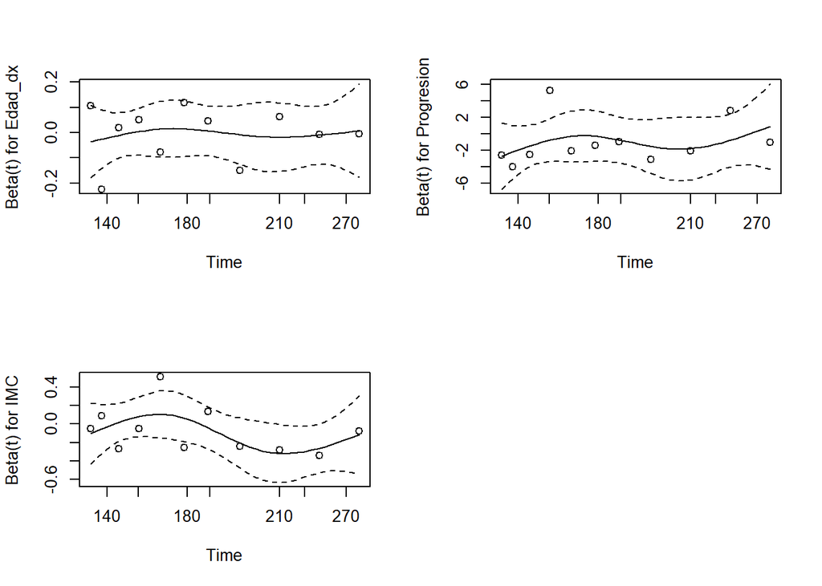

```r
par(mfrow=c(2,2))
plot(cox_test_ph)
```

Disease Progression (Progresion): The plot shows some points outside the confidence limits and some variation in the trend line. Although there is some evidence of non-proportionality, it is not conclusive. The proportional hazards assumption for Progresion might be slightly in doubt but not definitively violated.

Body Mass Index (IMC): The plot shows that the residuals are mostly within the confidence limits, similar to Edad_dx. This suggests that the proportional hazards assumption is not violated for IMC.

## Survival Curves from Multivariate Supervised Analysis

We analyze the survival curves obtained from the Cox regression models to understand the overall survival probability over time and compare the fit of different models.

## Survival Curves and forest plot for the Simplified Cox Model

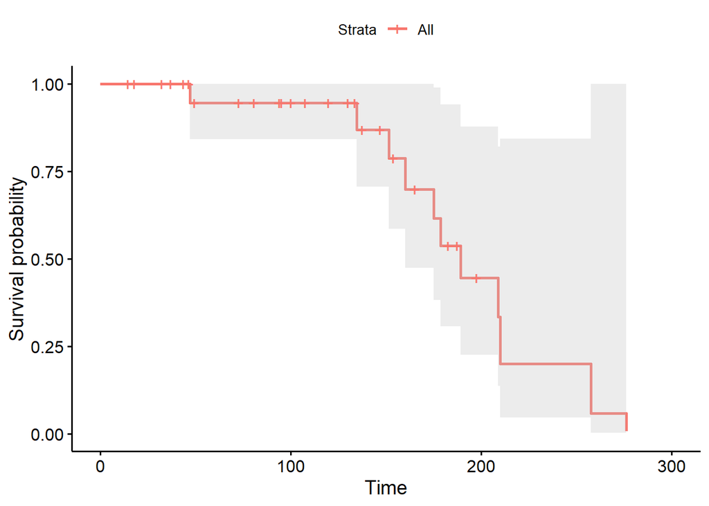

```r
ggsurvplot(survfit(cox_model_simplificado), data = datos, conf.int = TRUE, pval = TRUE)
```

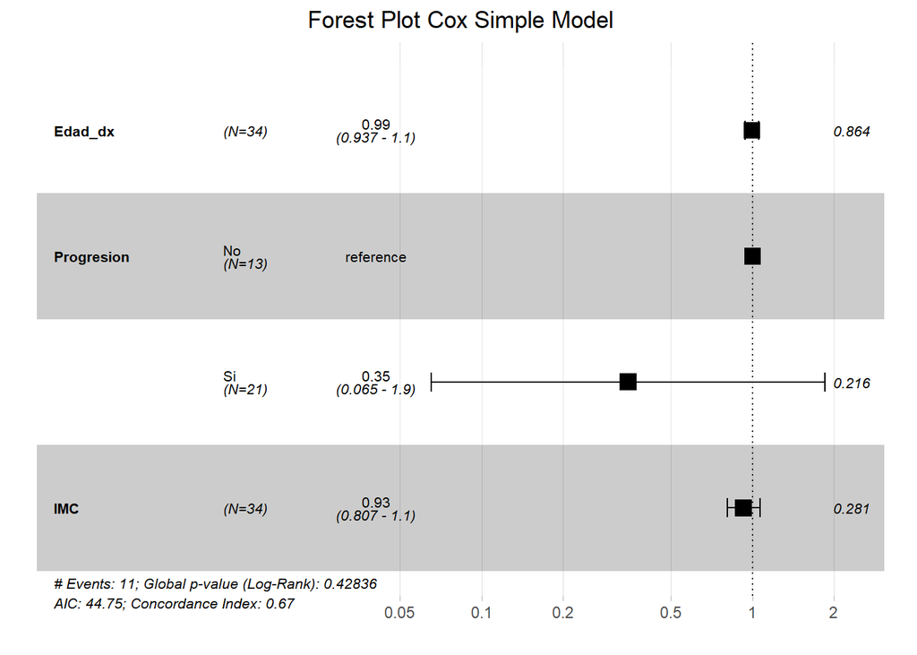

```r
ggforest(cox_model_simplificado, data = datos, main = "Forest Plot Cox Simple Model")
```

Survival Trend:

The confidence intervals in the simplified model are similar to those in the full model, indicating similar levels of uncertainty in the survival estimates. The widening of intervals over time suggests increasing variability in survival predictions as time progresses.

Survival Curves for the Full Cox Model

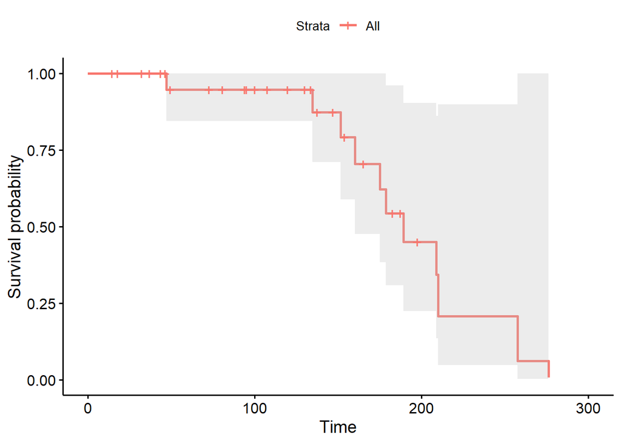

```r
ggsurvplot(survfit(cox_model), data = datos, conf.int = TRUE, pval = TRUE)
```

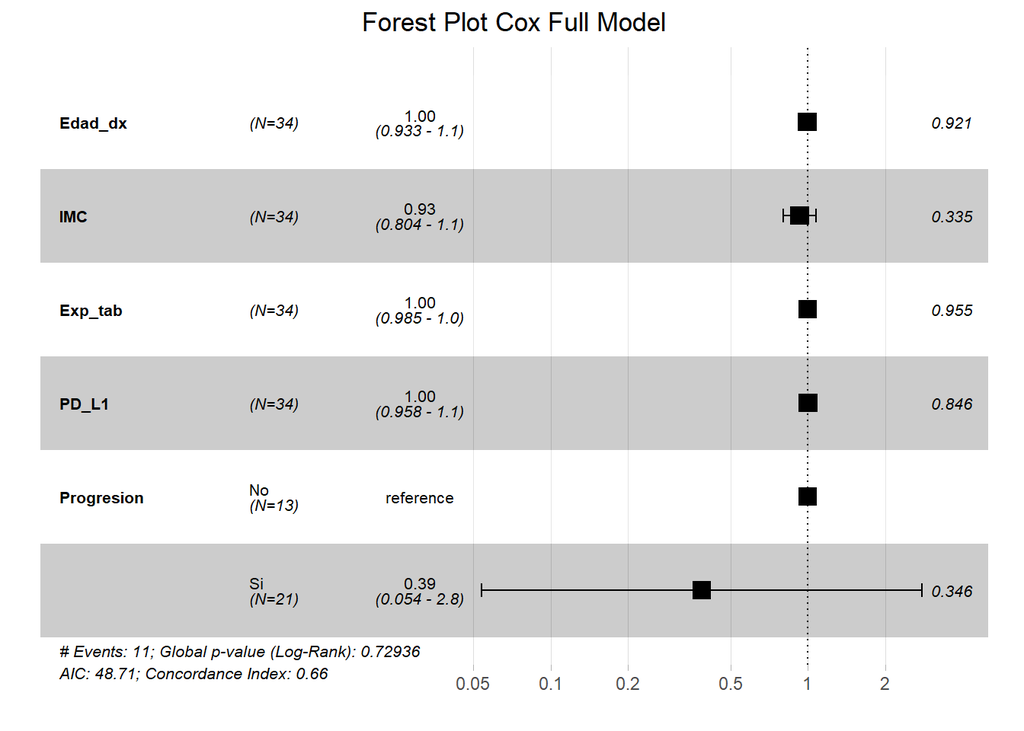

```r
ggforest(cox_model, data = datos, main = "Forest Plot Cox Full Model")
```

Confidence Intervals: The confidence intervals are relatively wide, indicating variability in the survival estimates, which may be due to the small sample size. The intervals widen further as time progresses, reflecting increasing uncertainty in survival estimates at later time points.

Both the full and simplified Cox models demonstrate similar survival trends, with consistent drops in survival probability at specific time intervals. The wide confidence intervals highlight the uncertainty in the survival estimates, suggesting the need for a larger sample size for more precise predictions.

Finally, we can see the overall p-value of the models of 0.43 and 0.73 which again do not generate any confidence and the equal confidence indices of ~0.66 which do not show a good discrimination between patients who survive and those who do not for the model. Similarly the values on the AIC fit according to the akaike information criterion are high, showing a poor fit.